# R Notebook

# Functions

```r
# function to plot ROC curve using ROCR library
plot_ROC <- function(true_outliers,
                     pvals,
                     outlier_cutoff = 1,
                     clr = TRUE,
                     ref_line = TRUE,
                     ...) {

  out_labels <- ifelse(rowSums(true_outliers == 0) >= outlier_cutoff, 0, 1)
  pred_val <- prediction(pvals, out_labels)
  perf_val <- performance(pred_val,"tpr","fpr")
  plot(perf_val,
       colorize = clr,
       xlim=c(0,1),
       ylim=c(0,1),
       ...)

  if (ref_line == TRUE) {
    abline(a=0, b= 1)
  }

}
```

# 0.975 Nonoutlier Rate

Here, we look at the case where 0.975 is “the proportion of non-replicable SNPs which are well behaved, or nonoutliers” (quoted from the MAMBA documentation).

```r
load(file = "data/prp_data/post_prp_data_pval_p975.rda")
load(file = "data/mamba_data/sim_mamba_mod_p975.rda")
load(file = "data/mamba_data/mamba_data_p975.rda")

prp_975 <- post_prp_data_pval
sim_mod_p975 <- sim_mod
mamba_data_p975 <- mamba_data

outliers_p975 <- mamba_data_p975$Ojk
mamba_ppr_p975 <- sim_mod_p975$ppr
```

First we look at the ROC curve for the MAMBA values at a 0.975 nonoutlier study rate.

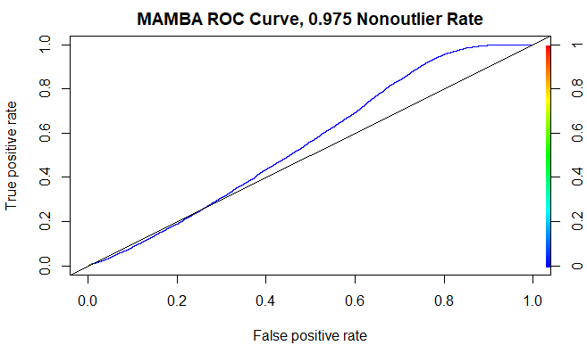

```r
plot_ROC(outliers_p975,
         mamba_ppr_p975,
         main = "MAMBA ROC Curve, 0.975 Nonoutlier Rate")
```

The PRP curve for the same nonoutlier rate is given below.

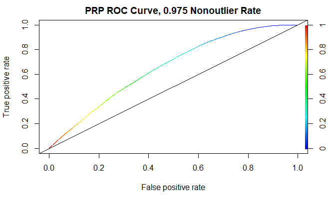

```r
plot_ROC(outliers_p975,
         prp_975,
         main = "PRP ROC Curve, 0.975 Nonoutlier Rate")
```

# 0.9 Nonoutlier Rate

Here, we look at the case where 0.9 is “the proportion of non-replicable SNPs which are well behaved, or nonoutliers.”

```r
load(file = "data/prp_data/post_prp_data_pval_p90.rda")
load(file = "data/mamba_data/sim_mamba_mod_p90.rda")
load(file = "data/mamba_data/mamba_data_p90.rda")


prp_90 <- post_prp_data_pval
sim_mod_p90 <- sim_mod
mamba_data_p90 <- mamba_data

outliers_p90 <- mamba_data_p90$Ojk
mamba_ppr_p90 <- sim_mod_p90$ppr
```

First we look at the ROC curve for the MAMBA values at a 0.9 nonoutlier study rate.

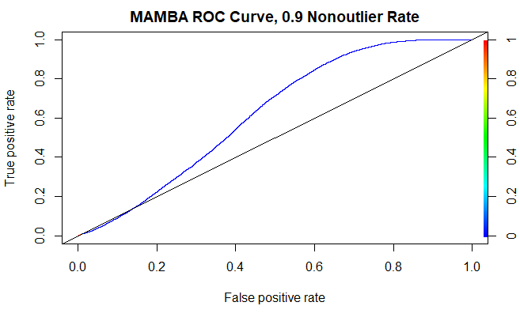

```r
plot_ROC(outliers_p90,
         mamba_ppr_p90,
         main = "MAMBA ROC Curve, 0.9 Nonoutlier Rate")
```

The PRP curve for the same nonoutlier rate is given below.

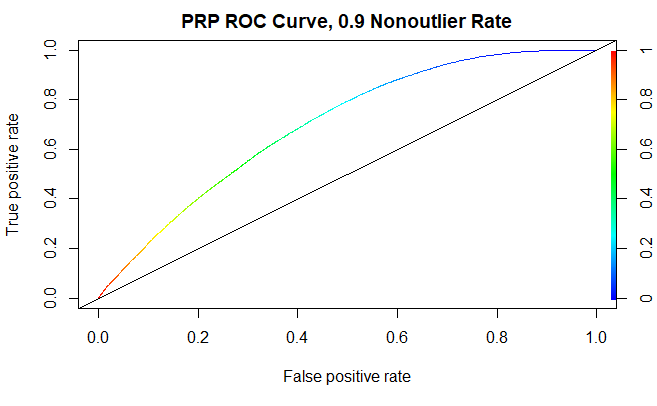

```r
plot_ROC(outliers_p90,
         prp_90,
         main = "PRP ROC Curve, 0.9 Nonoutlier Rate")
```

# 0.75 Nonoutlier Rate

Here, we look at the case where 0.75 is “the proportion of non-replicable SNPs which are well behaved, or nonoutliers.”

```r
load(file = "data/prp_data/post_prp_data_pval_p75.rda")
load(file = "data/mamba_data/sim_mamba_mod_p75.rda")
load(file = "data/mamba_data/mamba_data_p75.rda")

prp_75 <- post_prp_data_pval
sim_mod_p75 <- sim_mod
mamba_data_p75 <- mamba_data

outliers_p75 <- mamba_data_p75$Ojk
mamba_ppr_p75 <- sim_mod_p75$ppr
```

First we look at the ROC curve for the MAMBA values at a 0.75 nonoutlier study rate.

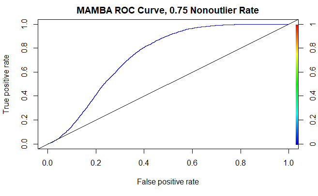

```r
plot_ROC(outliers_p75,
         mamba_ppr_p75,
         main = "MAMBA ROC Curve, 0.75 Nonoutlier Rate")
```

The PRP curve for the same nonoutlier rate is given below.

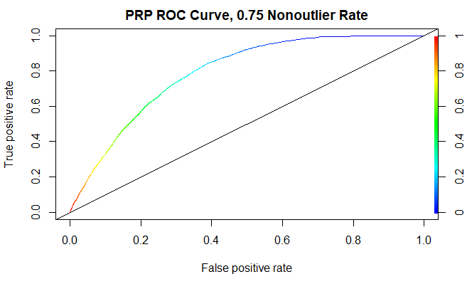

```r
plot_ROC(outliers_p75,
         prp_75,
         main = "PRP ROC Curve, 0.75 Nonoutlier Rate")
```

# 0.5 Nonoutlier Rate

We look at the case where 0.5 is “the proportion of non-replicable SNPs which are well behaved, or nonoutliers.”

```r
load(file = "data/prp_data/post_prp_data_pval_p50.rda")
load(file = "data/mamba_data/sim_mamba_mod_p50.rda")
load(file = "data/mamba_data/mamba_data_p50.rda")

prp_50 <- post_prp_data_pval
sim_mod_p50 <- sim_mod
mamba_data_p50 <- mamba_data

outliers_p50 <- mamba_data_p50$Ojk
mamba_ppr_p50 <- sim_mod_p50$ppr
```

First we look at the ROC curve for the MAMBA values at a 0.5 nonoutlier study rate.

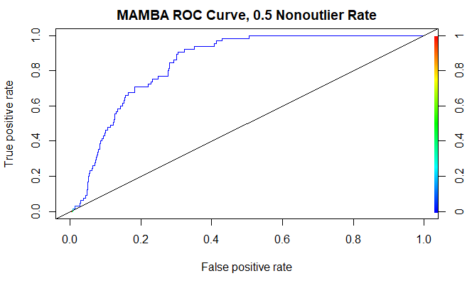

```r
plot_ROC(outliers_p50,
         mamba_ppr_p50,
         main = "MAMBA ROC Curve, 0.5 Nonoutlier Rate")
```

The PRP curve for the same nonoutlier rate is given below.

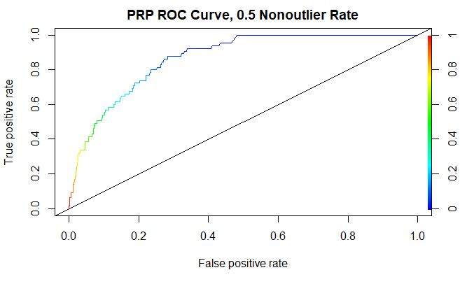

```r
plot_ROC(outliers_p50,
         prp_50,
         main = "PRP ROC Curve, 0.5 Nonoutlier Rate")
```

# 0.25 Nonoutlier Rate

Finally, we look at the case where 0.25 is “the proportion of non-replicable SNPs which are well behaved, or nonoutliers.” In this specific case, because every single SNP has at least one outlier, we change the cutoff for the number of outlier studies for the SNP to be considered not replicable.

```r
load(file = "data/prp_data/post_prp_data_pval_p25.rda")
load(file = "data/mamba_data/sim_mamba_mod_p25.rda")
load(file = "data/mamba_data/mamba_data_p25.rda")

prp_25 <- post_prp_data_pval
sim_mod_p25 <- sim_mod
mamba_data_p25 <- mamba_data

outliers_p25 <- mamba_data_p25$Ojk
mamba_ppr_p25 <- sim_mod_p25$ppr
```

First we look at the ROC curve for the MAMBA values at a 0.25 nonoutlier study rate. Here, we changed the number of cutoffs for a SNP to be considered not replicable to 3 studies (out of a total of 10 studies in the simulated data).

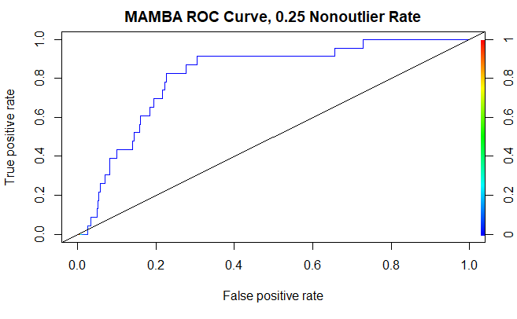

```r
plot_ROC(outliers_p25,
         mamba_ppr_p25,
         outlier_cutoff = 3,
         main = "MAMBA ROC Curve, 0.25 Nonoutlier Rate")
```

The PRP curve for the same nonoutlier rate is given below.

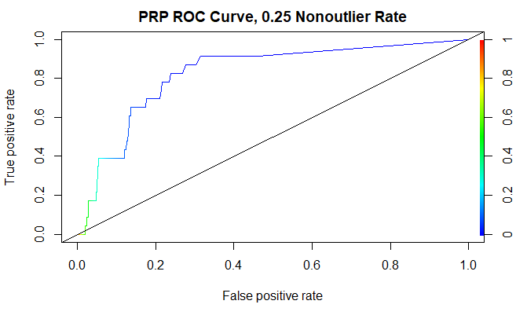

```r
plot_ROC(outliers_p25,
         prp_25,
         outlier_cutoff = 3,
         main = "PRP ROC Curve, 0.25 Nonoutlier Rate")
```